# Trabajo_Final Diplomado PUCP 2024

Ignacio Huaroto (20181741), Renato Rivera (20191964), Adriana Sierra (20182553) y Michel Cotrina (20181090)

# **Alumnos Matriculados en Educación Superior Universitaria**

La presente base de datos extrae el total de matriculados en educación superior universitaria a nivel nacional. Esta base de datos fue extraída del portal Tuni.pe, de la sección de base de datos (https://www.tuni.pe/datos). La información se generó a partir de los reportes de dichas universidades al Sistema de Información Universitaria (SIU).

# **Objetivo del Reporte**

El principal objetivo de este reporte es observar el patrón de matriculados a nivel nacional, teniendo como variables principales el género y la discapacidad. Este reporte puede servir como base para investigaciones de mercado en este rubro, para que las universidades puedan orientar de manera más directa su oferta. Asimismo es útil para el Estado en la medida en que permite reconocer el estado actual de las instituciones educativas públicas en comparacion a las privadas respecto al acceso a educación superior.

## 1. CARGA DE LA BBDD Y SELECCIÓN DE VARIABLES

Seleccionemos las variables que usaremos en todo el ejercicio.

```
## Rows: 2,664
## Columns: 16
## $ Universidad                                         <chr> "Asociación Civil …
## $ `Tipo de gestión`                                   <chr> "Privado", "Privad…
## $ `Grupos de programas`                               <chr> "Gestión y Adminis…
## $ Programa                                            <chr> "Administración", …
## $ `Departamento local`                                <chr> "Lima", "Lima", "L…
## $ `Provincia local`                                   <chr> "Lima", "Lima", "L…
## $ `Distrito local`                                    <chr> "Los Olivos", "Los…
## $ `Total de estudiantes`                              <dbl> 218, 290, 708, 416…
## $ `Número de matriculados hombres`                    <dbl> 84, 105, 1, 75, 16…
## $ `Número de matriculados mujeres`                    <dbl> 134, 185, 707, 341…
## $ `Número de matriculados menores de 17 años de edad` <dbl> NA, 6, 12, 4, 53, …
## $ `Número de matriculados de 18 a 24 años de edad`    <dbl> 136, 162, 397, 152…
## $ `Número de matriculados de 25 a 29 años de edad`    <dbl> 32, 61, 143, 101, …
## $ `Número de matriculados de 30 a 35 años de edad`    <dbl> 25, 33, 86, 74, 15…
## $ `Número de matriculados mayores de 36 años de edad` <dbl> 25, 28, 70, 85, 13…
## $ `Número de personas con discapacidad`               <dbl> 0, 0, 0, 1, 2, 0, …
```

Se aprecia que hay 16 variables y 2 664 casos en la BBDD. De estas 16 variables, 7 son categóricas y 9 son numéricas. Asegurémonos de que las últimas 9 sean identificadas como numéricas.

```
## Rows: 2,664
## Columns: 16
## $ Universidad                                         <chr> "Asociación Civil …
## $ `Tipo de gestión`                                   <chr> "Privado", "Privad…
## $ `Grupos de programas`                               <chr> "Gestión y Adminis…
## $ Programa                                            <chr> "Administración", …
## $ `Departamento local`                                <chr> "Lima", "Lima", "L…
## $ `Provincia local`                                   <chr> "Lima", "Lima", "L…
## $ `Distrito local`                                    <chr> "Los Olivos", "Los…
## $ `Total de estudiantes`                              <dbl> 218, 290, 708, 416…
## $ `Número de matriculados hombres`                    <dbl> 84, 105, 1, 75, 16…
## $ `Número de matriculados mujeres`                    <dbl> 134, 185, 707, 341…
## $ `Número de matriculados menores de 17 años de edad` <dbl> NA, 6, 12, 4, 53, …
## $ `Número de matriculados de 18 a 24 años de edad`    <dbl> 136, 162, 397, 152…
## $ `Número de matriculados de 25 a 29 años de edad`    <dbl> 32, 61, 143, 101, …
## $ `Número de matriculados de 30 a 35 años de edad`    <dbl> 25, 33, 86, 74, 15…
## $ `Número de matriculados mayores de 36 años de edad` <dbl> 25, 28, 70, 85, 13…
## $ `Número de personas con discapacidad`               <dbl> 0, 0, 0, 1, 2, 0, …
```

Se observa que en las variables numéricas (8 a 16) hay algunos NAs. Como una primera limpieza de la data, vamos a reemplazarlos con 0s para no perder información.

Buscamos que ya no haya NAS.

```
## [1] 0
```

## 2. ESTADÍSTICOS DESCRIPTIVOS

En la presente sección, desarrollaremos los estadísticos descriptivos de las variables identificadas.

Empecemos con el número de universidades.

```
## [1] 91
```

Se puede observar que, hay 91 universidades licenciadas por Sunedu a nivel nacional, registradas en esta base de datos.

Ahora, identificamos el tipo de gestión de las universidades identificadas.

```
##
## Privado Público
##    1640    1024
```

```
##
##  Privado  Público
## 61.56156 38.43844
```

Ahora, identificamos las categorías que agrupan a las distintas carreras o programas que se dictan en las universidades identificadas.

```
## [1] 78
```

```
##
## Gestión y Administración Contabilidad e Impuestos       Sistemas y Cómputo
##                      266                      144                      127
```

Se observa que, hay 78 grupos de programas a nivel nacional. De estos, se puede observar que el grupo que se dicta con mayor frecuencia a nivel nacional es Gestión y Administración (266 casos), seguido por Contabilidad e Impuestos (144 casos) y luego por Sistemas y cómputo (127 casos). Estos representan el 21,50%, 11,64% y 10,26% de los casos, respectivamente.

Ahora, realizamos el mismo proceso con los programas o carreras que dictan las universidades seleccionadas.

```
## [1] 700
```

```
##
## Ingeniería Civil          Derecho       Psicología
##              103               93               89
```

Se aprecia que hay 700 programas o carreras que se dictan a nivel nacional. De estas, las que cuentan con mayor incidencia de matrícula son Ingeniería Civil (103 casos), Derecho (93 casos) y Psicología (89 casos), con el 13,93%, 12,58% y 12,04%, respectivamente.

A continuación, se muestran los departamentos, provincias y distritos en donde hay mayor incidencia de matriculados.

```
## [1] 25
```

```
## # A tibble: 25 × 2
##    Departamento matriculados
##    <chr>               <dbl>
##  1 Lima               582899
##  2 Arequipa            88379
##  3 La Libertad         87515
##  4 Junín               63903
##  5 Piura               56329
##  6 Lambayeque          55505
##  7 Cusco               51492
##  8 Ica                 34690
##  9 Áncash              29648
## 10 Cajamarca           28846
## # ℹ 15 more rows
```

Por su parte, hay 74 provincias en todo el Perú que cuentan con por lo menos una universidad licenciada por Sunedu. Además, la mayor incidencia de matriculados está en Lima (568 884), Arequipa (87 485) y Trujillo (83 183).

```
## [1] 74
```

```
##  [1] "Lima"                    "Tambopata"
##  [3] "Canchis"                 "La Convención"
##  [5] "Cusco"                   "Ica"
##  [7] "Chincha"                 "Arequipa"
##  [9] "Trujillo"                "Chiclayo"
## [11] "Atalaya"                 "Rioja"
## [13] "Morropón"                "Huaura"
## [15] "Tarma"                   "Moyobamba"
## [17] "Huaraz"                  "Chepén"
## [19] "Prov. Const. del Callao" "San Martín"
## [21] "Santa"                   "Piura"
## [23] "Huancayo"                "Huánuco"
## [25] "Leoncio Prado"           "Alto Amazonas"
## [27] "Chota"                   "Huanta"
## [29] "Tayacaja"                "Pasco"
```

[output cut: 22 more lines]

```
## # A tibble: 74 × 2
##    Provincia matriculados
##    <chr>            <dbl>
##  1 Lima            568884
##  2 Arequipa         87485
##  3 Trujillo         83183
##  4 Huancayo         58613
##  5 Chiclayo         55505
##  6 Piura            54105
##  7 Cusco            46678
##  8 Ica              25791
##  9 Cajamarca        23491
## 10 Huánuco          19781
## # ℹ 64 more rows
```

```
## [1] 129
```

```
##   [1] "Los Olivos"                    "Pueblo Libre"
##   [3] "San Miguel"                    "Chorrillos"
##   [5] "Tambopata"                     "Sicuani"
##   [7] "Santa Ana"                     "San Jerónimo"
##   [9] "Ica"                           "Chincha Alta"
##  [11] "Villa El Salvador"             "Arequipa"
##  [13] "Moche"                         "Trujillo"
##  [15] "Chiclayo"                      "Raymondi"
##  [17] "Nueva Cajamarca"               "Chulucanas"
##  [19] "Huacho"                        "Vegueta"
##  [21] "Santiago de Surco"             "Tarma"
##  [23] "Moyobamba"                     "Independencia"
##  [25] "Chepen"                        "Callao"
##  [27] "Cacatachi"                     "Ate"
##  [29] "Pimentel"                      "San Juan de Lurigancho"
```

[output cut: 50 more lines]

```
## # A tibble: 129 × 2
##    Distrito               matriculados
##    <chr>                         <dbl>
##  1 Lima                         111691
##  2 Los Olivos                    97196
##  3 Arequipa                      77779
##  4 Santiago de Surco             66974
##  5 Trujillo                      50967
##  6 Huancayo                      45513
##  7 Villa El Salvador             41649
##  8 San Miguel                    40876
##  9 La Molina                     39844
## 10 San Juan de Lurigancho        36430
## # ℹ 119 more rows
```

A continuación, se presentan los estadísticos descriptivos del número total de estudiantes matriculados a nivel nacional.

```
## [1] 1230230
```

```
##    Min. 1st Qu.  Median    Mean 3rd Qu.    Max.
##     1.0   148.0   289.0   461.8   534.0  6059.0
```

Se aprecia que, a nivel nacional, hay un total de 1 230 230 alumnos matriculados en universidades licenciadas por Sunedu.

Además, se aprecia que, en promedio, 461 matriculados por carrera o programa. Sin embargo, hay que tener en cuenta que la distribución de esta variable no es normal, por eso la diferencia significativa entre la media (461.8) y la mediana (289), así como entre los valores mínimo (1) y máximo (6 059).

Aquello es más fácil de visualizar en un boxplot o gráfico de caja. En este, se observa que hay muchos valores atípicos o outliers referente al número de matriculados por carrera.

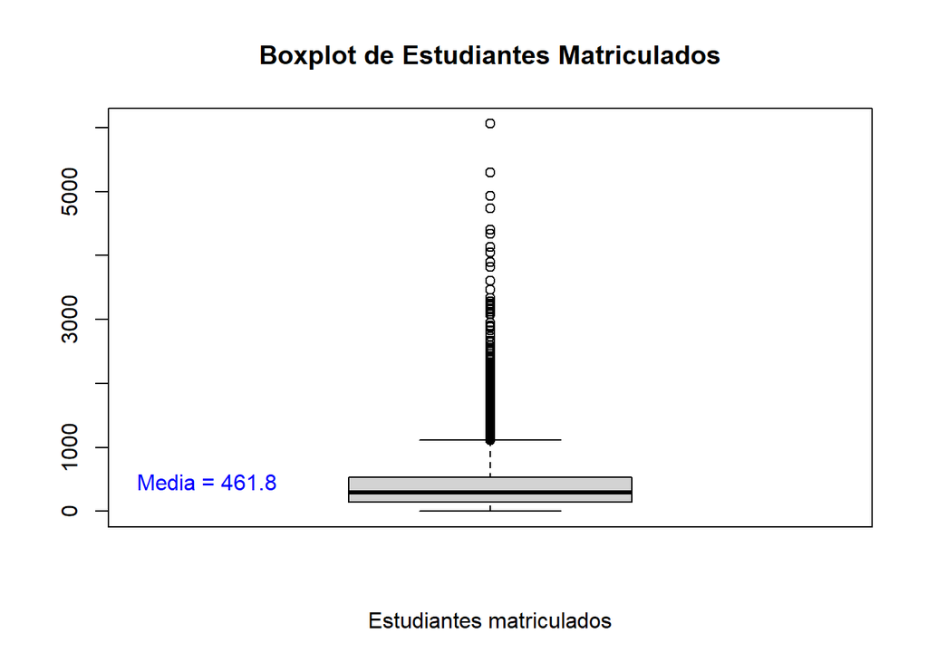

```r
print(cuartiles)
```

```
## 25% 50% 75%
## 148 289 534
```

```r
print(media)
```

```
## [1] 461.798
```

A continuación, se presentan los descriptivos del número de estudiantes matriculados hombres y su boxplot respectivo.

```
##    Min. 1st Qu.  Median    Mean 3rd Qu.    Max.
##     0.0    54.0   132.0   224.3   273.2  3109.0
```

```
## [1] 597598
```

```
## [1] 48.57612
```

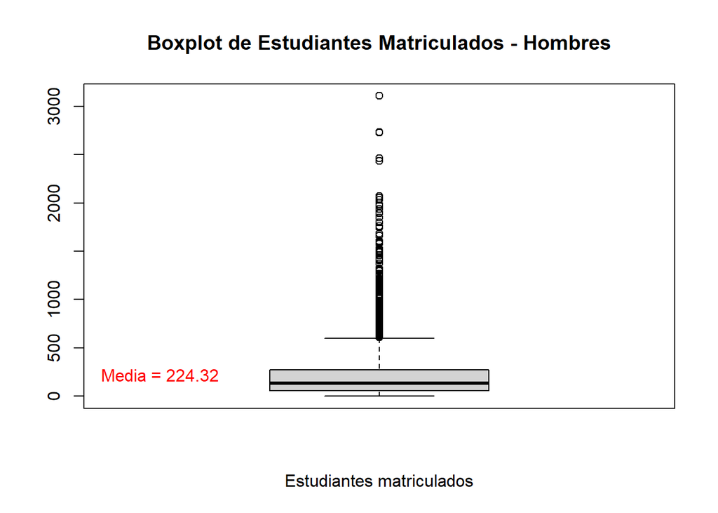

```
##    25%    50%    75%
##  54.00 132.00 273.25
```

```
## [1] 224.3236
```

Se observa que el promedio de hombres matriculados por cada programa es de 224. También tiene una distribución de tipo no normal, debido a la diferencia de los valores de su media y mediana. Por otro lado, se observa que en total hay 597.598 hombres matriculados a nivel nacional, lo que corresponde a un 48.6% del total de matriculados.

Ahora, veamos los descriptivos de las mujeres matriculadas y su boxplot respectivo. En este se observa que en total hay 632 632 mujeres matriculadas a nivel nacional, lo que corresponde a un 51.4% del total de matriculados. Además, se observa que el promedio de mujeres matriculadas por cada programa es de 238. También tiene una distribución de tipo no normal, debido a la diferencia de los valores de su media y mediana.

```
##    Min. 1st Qu.  Median    Mean 3rd Qu.    Max.
##     0.0    51.0   131.0   237.5   278.0  3675.0
```

```
## [1] 632632
```

```
## [1] 51.42388
```

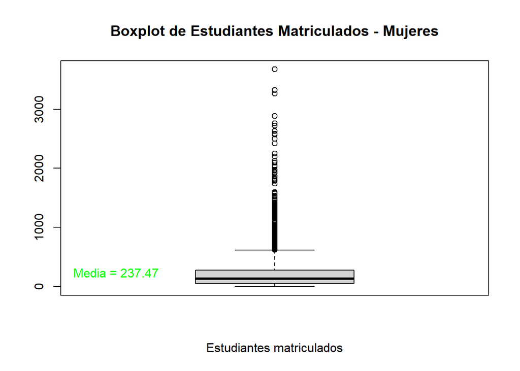

Ahora, ¿qué pasaría si buscamos la distribución de hombres y mujeres matriculadas por el tipo de gestión de las universidades?

```
## # A tibble: 2 × 3
##   `Tipo de gestión` total_hombres_por_gestion porcentaje
##   <chr>                                 <dbl>      <dbl>
## 1 Privado                              438375       73.4
## 2 Público                              159223       26.6
```

```
## # A tibble: 2 × 3
##   `Tipo de gestión` total_mujeres_por_gestion porcentaje
##   <chr>                                 <dbl>      <dbl>
## 1 Privado                              494988       78.2
## 2 Público                              137644       21.8
```

La distribución de hombres matriculados muestra que el 73,35% están en instituciones de gestión privada, mientras que el 26,64% están en la gestión pública. Una tendencia similar se observa entre las mujeres, con un 78,24% matriculadas en la gestión privada y un 21,75% matriculadas en la gestión pública.

Acto seguido, se presentan los estadísticos descriptivos del número de matriculados por las 5 variables de rango de edad.

Primero, se presenta el análisis de la variable de menores de edad matriculados, agrupada por departamento, tipo de gestión, universidad y grupos de programas.

```
## [1] 64163
```

```
## [1] 5.215529
```

```
## # A tibble: 25 × 3
##    Departamento total_menores_por_dep porcentaje
##    <chr>                        <dbl>      <dbl>
##  1 Lima                         28246      44.0
##  2 La Libertad                   4629       7.21
##  3 Piura                         4450       6.94
##  4 Lambayeque                    4295       6.69
##  5 Arequipa                      3666       5.71
##  6 Junín                         3130       4.88
##  7 Ica                           2713       4.23
##  8 Cusco                         2263       3.53
##  9 Áncash                        1682       2.62
## 10 Cajamarca                     1375       2.14
## # ℹ 15 more rows
```

```
## # A tibble: 2 × 3
##   `Tipo de gestión` total_menores_por_gestion porcentaje
##   <chr>                                 <dbl>      <dbl>
## 1 Privado                               52902       82.4
## 2 Público                               11261       17.6
```

```
## # A tibble: 91 × 3
##    Universidad                                  total_menores_por_uni porcentaje
##    <chr>                                                        <dbl>      <dbl>
##  1 Universidad Tecnológica del Perú S.A.C.                      10284      16.0
##  2 Universidad César Vallejo S.A.C.                              8017      12.5
##  3 Universidad Privada del Norte S.A.C.                          5522       8.61
##  4 Universidad Peruana de Ciencias Aplicadas S…                  4285       6.68
##  5 Universidad Continental S.A.C.                                1827       2.85
##  6 Universidad Privada Antenor Orrego                            1749       2.73
##  7 Pontificia Universidad Católica del Perú                      1662       2.59
##  8 Universidad de Lima                                           1569       2.45
##  9 Universidad de San Martín de Porres                           1263       1.97
## 10 Universidad Señor de Sipán S.A.C.                             1213       1.89
## # ℹ 81 more rows
```

```
## # A tibble: 78 × 3
##    `Grupos de programas`                       total_menores_por_gr…¹ porcentaje
##    <chr>                                                        <dbl>      <dbl>
##  1 Derecho Público                                               7012      10.9
##  2 Gestión y Administración                                      6021       9.38
##  3 Psicología                                                    5666       8.83
##  4 Sistemas y Cómputo                                            5262       8.20
##  5 Construcción e Ingeniería Civil                               4527       7.06
##  6 Industria y Productos Transformados (excep…                   3632       5.66
##  7 Arquitectura y Urbanismo                                      3329       5.19
##  8 Medicina                                                      2946       4.59
##  9 Enfermería                                                    2896       4.51
## 10 Contabilidad e Impuestos                                      2480       3.87
## # ℹ 68 more rows
## # ℹ abbreviated name: ¹total_menores_por_grupo
```

El número total de alumnos menores de 17 años matriculados en educación superior universitaria a nivel nacional es de 64 163, representando el 5,21% de los estudiantes. Estos se concentran en Lima (44,02%) y La Libertad (7,21%). Respecto al tipo de gestión, estos suelen estar en su mayoría en la privada (82,44%), están en su mayoría en la Universidad Tecnológica del Perú S.A.C. (16.02%) y suelen estudiar Derecho Público (10.92%).

Segundo, analicemos la variable de matriculados entre 18 y 24 años de edad, agrupándola también por departamento, universidad, tipo de gestión y grupos de programas.

```
## [1] 836092
```

```
## [1] 67.96225
```

```
## # A tibble: 25 × 3
##    Departamento total_1824_por_dep porcentaje
##    <chr>                     <dbl>      <dbl>
##  1 Lima                     382967      45.8
##  2 La Libertad               61306       7.33
##  3 Arequipa                  59935       7.17
##  4 Piura                     42174       5.04
##  5 Junín                     41485       4.96
##  6 Lambayeque                38220       4.57
##  7 Cusco                     33074       3.96
##  8 Ica                       24941       2.98
##  9 Áncash                    21650       2.59
## 10 Cajamarca                 21377       2.56
## # ℹ 15 more rows
```

```
## # A tibble: 2 × 3
##   `Tipo de gestión` total_1824_por_gestion porcentaje
##   <chr>                              <dbl>      <dbl>
## 1 Privado                           612883       73.3
## 2 Público                           223209       26.7
```

```
## # A tibble: 91 × 3
##    Universidad                                     total_1824_por_uni porcentaje
##    <chr>                                                        <dbl>      <dbl>
##  1 Universidad Tecnológica del Perú S.A.C.                      90591      10.8
##  2 Universidad César Vallejo S.A.C.                             89881      10.8
##  3 Universidad Privada del Norte S.A.C.                         73500       8.79
##  4 Universidad Peruana de Ciencias Aplicadas S.A.…              48511       5.80
##  5 Universidad Continental S.A.C.                               24505       2.93
##  6 Universidad Nacional Mayor de San Marcos                     23934       2.86
##  7 Universidad Privada Antenor Orrego                           21651       2.59
##  8 Universidad de Lima                                          20982       2.51
##  9 Universidad de San Martín de Porres                          20979       2.51
## 10 Pontificia Universidad Católica del Perú                     19839       2.37
## # ℹ 81 more rows
```

```
## # A tibble: 78 × 3
##    `Grupos de programas`                         total_1824_por_grupo porcentaje
##    <chr>                                                        <dbl>      <dbl>
##  1 Gestión y Administración                                     87957      10.5
##  2 Derecho Público                                              83124       9.94
##  3 Psicología                                                   66868       8.00
##  4 Construcción e Ingeniería Civil                              56865       6.80
##  5 Industria y Productos Transformados (excepto…                51267       6.13
##  6 Sistemas y Cómputo                                           42669       5.10
##  7 Contabilidad e Impuestos                                     40134       4.80
##  8 Medicina                                                     37525       4.49
##  9 Arquitectura y Urbanismo                                     36518       4.37
## 10 Enfermería                                                   29108       3.48
## # ℹ 68 more rows
```

El número total de alumnos entre 18 y 24 años matriculados en educación superior universitaria a nivel nacional es de 836 092, representando el 67,96% de los estudiantes universitarios. Estos se concentran en Lima (45,80%) y La Libertad (7,33%). Respecto al tipo de gestión, estos suelen estar en su mayoría en la privada (73,30%), están en su mayoría en la Universidad Tecnológica del Perú S.A.C. (10.83%) y suelen estudiar Gestión y Administración (10.52%).

Tercero, analicemos la variable de matriculados entre 25 y 29 años de edad, agrupándola también por departamento, universidad, tipo de gestión y grupos de programas.

```
## [1] 184318
```

```
## [1] 14.9824
```

```
## # A tibble: 25 × 3
##    Departamento total_2529_por_dep porcentaje
##    <chr>                     <dbl>      <dbl>
##  1 Lima                      91985      49.9
##  2 Arequipa                  14616       7.93
##  3 La Libertad               12234       6.64
##  4 Junín                     10187       5.53
##  5 Cusco                      9629       5.22
##  6 Lambayeque                 7133       3.87
##  7 Piura                      5883       3.19
##  8 Huánuco                    4085       2.22
##  9 Áncash                     3971       2.15
## 10 Cajamarca                  3857       2.09
## # ℹ 15 more rows
```

```
## # A tibble: 2 × 3
##   `Tipo de gestión` total_2529_por_gestion porcentaje
##   <chr>                              <dbl>      <dbl>
## 1 Privado                           140588       76.3
## 2 Público                            43730       23.7
```

```
## # A tibble: 91 × 3
##    Universidad                                     total_2529_por_uni porcentaje
##    <chr>                                                        <dbl>      <dbl>
##  1 Universidad Tecnológica del Perú S.A.C.                      25272      13.7
##  2 Universidad César Vallejo S.A.C.                             22920      12.4
##  3 Universidad Privada del Norte S.A.C.                         17587       9.54
##  4 Universidad Continental S.A.C.                               10908       5.92
##  5 Universidad Peruana de Ciencias Aplicadas S.A.…               8866       4.81
##  6 Universidad Nacional Mayor de San Marcos                      5125       2.78
##  7 Universidad de San Martín de Porres                           4650       2.52
##  8 Universidad San Ignacio de Loyola S.R.L.                      3872       2.10
##  9 Universidad Privada Norbert Wiener S.A.                       3720       2.02
## 10 Universidad Nacional de San Agustín de Arequipa               3539       1.92
## # ℹ 81 more rows
```

```
## # A tibble: 78 × 3
##    `Grupos de programas`                         total_2529_por_grupo porcentaje
##    <chr>                                                        <dbl>      <dbl>
##  1 Gestión y Administración                                     21317      11.6
##  2 Derecho Público                                              16910       9.17
##  3 Construcción e Ingeniería Civil                              15580       8.45
##  4 Industria y Productos Transformados (excepto…                15017       8.15
##  5 Psicología                                                   13058       7.08
##  6 Contabilidad e Impuestos                                     12042       6.53
##  7 Sistemas y Cómputo                                            7941       4.31
##  8 Medicina                                                      7805       4.23
##  9 Arquitectura y Urbanismo                                      6872       3.73
## 10 Enfermería                                                    5720       3.10
## # ℹ 68 more rows
```

El número total de alumnos entre 25 y 29 años matriculados en educación superior universitaria a nivel nacional es de 184 318, representando el 14,98% de los estudiantes universitarios. Estos se concentran en Lima (49,90%) y Arequipa (7,92%). Respecto al tipo de gestión, estos suelen estar en su mayoría en la privada (76,27%), están en su mayoría en la Universidad Tecnológica del Perú S.A.C. (13.71%) y suelen estudiar Gestión y Administración (11.56%).

Cuarto, analicemos la variable de matriculados entre 30 y 35 años de edad, agrupandolas también por departamento, universidad, tipo de gestión y grupos de programas.

```
## [1] 83674
```

```
## [1] 6.801492
```

```
## # A tibble: 25 × 3
##    Departamento total_3035_por_dep porcentaje
##    <chr>                     <dbl>      <dbl>
##  1 Lima                      44477      53.2
##  2 Arequipa                   6081       7.27
##  3 La Libertad                5525       6.60
##  4 Junín                      5146       6.15
##  5 Cusco                      4070       4.86
##  6 Lambayeque                 3349       4.00
##  7 Piura                      2265       2.71
##  8 Huánuco                    1941       2.32
##  9 Ica                        1759       2.10
## 10 Áncash                     1438       1.72
## # ℹ 15 more rows
```

```
## # A tibble: 2 × 3
##   `Tipo de gestión` total_3035_por_gestion porcentaje
##   <chr>                              <dbl>      <dbl>
## 1 Privado                            71659       85.6
## 2 Público                            12015       14.4
```

```
## # A tibble: 91 × 3
##    Universidad                                     total_3035_por_uni porcentaje
##    <chr>                                                        <dbl>      <dbl>
##  1 Universidad Tecnológica del Perú S.A.C.                      13991      16.7
##  2 Universidad César Vallejo S.A.C.                             12548      15.0
##  3 Universidad Privada del Norte S.A.C.                          9172      11.0
##  4 Universidad Continental S.A.C.                                7626       9.11
##  5 Universidad Peruana de Ciencias Aplicadas S.A.…               3710       4.43
##  6 Universidad Privada Norbert Wiener S.A.                       2704       3.23
##  7 Universidad San Ignacio de Loyola S.R.L.                      1983       2.37
##  8 Universidad de Huánuco                                        1492       1.78
##  9 Universidad Católica de Trujillo Benedicto XVI                1356       1.62
## 10 Universidad Privada San Juan Bautista S.A.C.                  1356       1.62
## # ℹ 81 more rows
```

```
## # A tibble: 78 × 3
##    `Grupos de programas`                         total_3035_por_grupo porcentaje
##    <chr>                                                        <dbl>      <dbl>
##  1 Gestión y Administración                                     10874      13.0
##  2 Derecho Público                                              10713      12.8
##  3 Industria y Productos Transformados (excepto…                 8233       9.84
##  4 Construcción e Ingeniería Civil                               7258       8.67
##  5 Psicología                                                    6502       7.77
##  6 Contabilidad e Impuestos                                      6349       7.59
##  7 Enfermería                                                    3626       4.33
##  8 Sistemas y Cómputo                                            3545       4.24
##  9 Medicina                                                      2478       2.96
## 10 Mecánica y Metalúrgica                                        1739       2.08
## # ℹ 68 more rows
```

El número total de alumnos entre 30 y 35 años matriculados en educación superior universitaria a nivel nacional es de 83 674, representando menos del 6,80% de los estudiantes universitarios. Estos se concentran en Lima (53,15%) y Arequipa (7,26%). Respecto al tipo de gestión, estos suelen estar en su mayoría en la privada (85,64%), están en su mayoría en la Universidad Tecnológica del Perú S.A.C. (16.72%) y suelen estudiar Gestión y Administración (12.99%).

Quinto, analicemos la variable de matriculados mayores de 36 años de edad, agrupándola también por departamento, universidad, tipo de gestión y grupos de programas.

```
## [1] 61819
```

```
## [1] 5.024995
```

```
## # A tibble: 25 × 3
##    Departamento total_36_por_dep porcentaje
##    <chr>                   <dbl>      <dbl>
##  1 Lima                    35143      56.8
##  2 Arequipa                 4061       6.57
##  3 Junín                    3936       6.37
##  4 La Libertad              3818       6.18
##  5 Lambayeque               2503       4.05
##  6 Cusco                    2447       3.96
##  7 Ica                      1676       2.71
##  8 Piura                    1554       2.51
##  9 Huánuco                  1374       2.22
## 10 Áncash                    904       1.46
## # ℹ 15 more rows
```

```
## # A tibble: 2 × 3
##   `Tipo de gestión` total_36_por_gestion porcentaje
##   <chr>                            <dbl>      <dbl>
## 1 Privado                          55189       89.3
## 2 Público                           6630       10.7
```

```
## # A tibble: 91 × 3
##    Universidad                                      total_36_por_uni porcentaje
##    <chr>                                                       <dbl>      <dbl>
##  1 Universidad Tecnológica del Perú S.A.C.                     10715      17.3
##  2 Universidad César Vallejo S.A.C.                             9921      16.0
##  3 Universidad Continental S.A.C.                               7022      11.4
##  4 Universidad Privada del Norte S.A.C.                         6526      10.6
##  5 Universidad Peruana de Ciencias Aplicadas S.A.C.             2399       3.88
##  6 Universidad Privada Norbert Wiener S.A.                      2218       3.59
##  7 Universidad San Ignacio de Loyola S.R.L.                     1254       2.03
##  8 Universidad Privada San Juan Bautista S.A.C.                 1156       1.87
##  9 Universidad Católica de Trujillo Benedicto XVI               1145       1.85
## 10 Universidad de Huánuco                                       1141       1.85
## # ℹ 81 more rows
```

```
## # A tibble: 78 × 3
##    `Grupos de programas`                           total_36_por_grupo porcentaje
##    <chr>                                                        <dbl>      <dbl>
##  1 Derecho Público                                              13189      21.3
##  2 Gestión y Administración                                      7827      12.7
##  3 Psicología                                                    5522       8.93
##  4 Industria y Productos Transformados (excepto a…               5403       8.74
##  5 Construcción e Ingeniería Civil                               4688       7.58
##  6 Contabilidad e Impuestos                                      3779       6.11
##  7 Enfermería                                                    2923       4.73
##  8 Sistemas y Cómputo                                            2569       4.16
##  9 Farmacia                                                      1505       2.43
## 10 Medicina                                                      1476       2.39
## # ℹ 68 more rows
```

Por último, analicemos el número de alumnos matriculados con alguna discapacidad, agrupándolo por las mismas variables.

```
## [1] 2748
```

```
## [1] 0.2233729
```

```
## # A tibble: 25 × 3
##    Departamento total_discapacidad_por_dep porcentaje
##    <chr>                             <dbl>      <dbl>
##  1 Lima                                819      29.8
##  2 Arequipa                            189       6.88
##  3 Cusco                               183       6.66
##  4 Huánuco                             179       6.51
##  5 Cajamarca                           169       6.15
##  6 La Libertad                         148       5.39
##  7 Piura                               127       4.62
##  8 Puno                                127       4.62
##  9 Junín                               118       4.29
## 10 Ica                                  98       3.57
## # ℹ 15 more rows
```

```
## # A tibble: 2 × 3
##   `Tipo de gestión` total_discapacidad_por_gestion porcentaje
##   <chr>                                      <dbl>      <dbl>
## 1 Privado                                     1469       53.5
## 2 Público                                     1279       46.5
```

```
## # A tibble: 91 × 3
##    Universidad                                 total_discapacidad_p…¹ porcentaje
##    <chr>                                                        <dbl>      <dbl>
##  1 Universidad César Vallejo S.A.C.                               241       8.77
##  2 Universidad Tecnológica del Perú S.A.C.                        215       7.82
##  3 Universidad Privada del Norte S.A.C.                           119       4.33
##  4 Universidad Continental S.A.C.                                 113       4.11
##  5 Universidad Nacional Hermilio Valdizán de …                    100       3.64
##  6 Universidad Nacional Mayor de San Marcos                        91       3.31
##  7 Universidad Nacional de San Antonio Abad d…                     87       3.17
##  8 Universidad Nacional del Altiplano                              87       3.17
##  9 Universidad Nacional de Cajamarca                               86       3.13
## 10 Universidad Nacional de San Agustín de Are…                     68       2.47
## # ℹ 81 more rows
## # ℹ abbreviated name: ¹total_discapacidad_por_uni
```

```
## # A tibble: 78 × 3
##    `Grupos de programas`                       total_discapacidad_p…¹ porcentaje
##    <chr>                                                        <dbl>      <dbl>
##  1 Derecho Público                                                427      15.5
##  2 Psicología                                                     275      10.0
##  3 Gestión y Administración                                       216       7.86
##  4 Construcción e Ingeniería Civil                                202       7.35
##  5 Sistemas y Cómputo                                             177       6.44
##  6 Medicina                                                       169       6.15
##  7 Contabilidad e Impuestos                                       157       5.71
##  8 Enfermería                                                     108       3.93
##  9 Industria y Productos Transformados (excep…                     76       2.77
## 10 Arquitectura y Urbanismo                                        65       2.37
## # ℹ 68 more rows
## # ℹ abbreviated name: ¹total_discapacidad_por_grupo
```

Se observa que en total exiten 2748 personas con discapacidad matriculados en educación superior universitaria a nivel nacional. Representando el 0.22% del universo total de estudiantes. Estos se concentran en Lima (29,80%) y Arequipa (6,87%). Respecto al tipo de gestión, estos suelen estar en su mayoría en la privada (53,45%), están en su mayoría en la Universidad César Vallejo S.A.C. (8,77%) y suelen estudiar Derecho Público (15.53%).

## 3. VISUALIZACIÓN DE DATOS: GRÁFICOS

En la presente sección, se añaden los gráficos de las variables analizadas anteriormente, con el fin de hacer más sencilla su interpretación.

#### 3.1. Porcentaje de Matriculados por Tipo de gestión según área geográfica

Se creará un gráfico de barras que permita visualizar al porcentaje de matriculados por tipo de gestión según área geográfica. Esto implica conocer la proporción de estudiantes en instituciones educativas universitarias privadas o públicas a nivel nacional, en Lima Metropolitana y a nivel de provincias en general (exceptuando Lima Metropolitana)

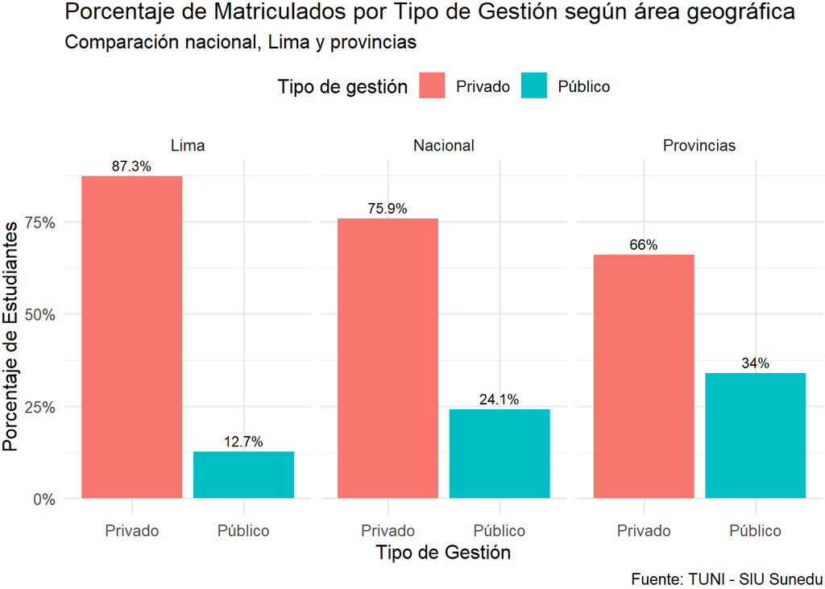

Este primer gráfico permite adr cuenta que la gran mayoría de estudiantes en Lima Metropolitana están matriculados en instituciones privadas (87.3%). Hay una fuerte inclinación hacia la educación privada en la capital. A nivel nacional la tendencia de matriculados en instituciones públicas aumenta al doble, un 24% de estudiantes está matriculado. Este aumento se explica por la cantidad de alumnos matriculados en universidad públicas a nivel de provincias (34%), lo que representa un aumento notable en comparación a Lima Metropolitana y el promedio nacional. Pero igual se mantiene una preferencia por la educación privada. En general esto podría sugerir niveles distintos de accesibilidad y calidad educativa entre Lima Metropolitana y provincias a nivel nacional.

#### 3.2 Top 5 universidades con el mayor porcentaje de matriculados en Perú

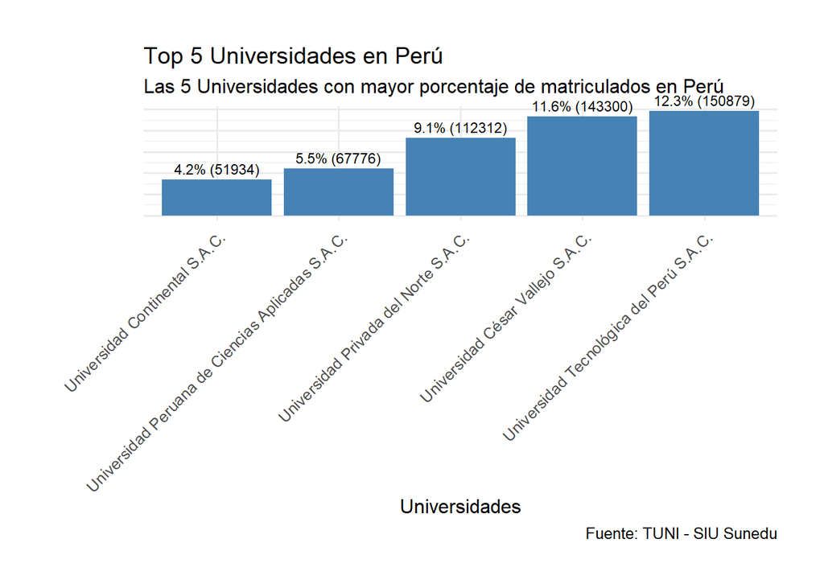

El gráfico muestra las cinco universidades con mayor cantidad de matriculados en Perú, destacando que la Universidad Tecnológica del Perú S.A.C. lidera con un 12.3% del total, seguida por la Universidad César Vallejo S.A.C. con un 11.6%. Las otras universidades, como la Universidad Privada del Norte S.A.C. y la Universidad Peruana de Ciencias Aplicadas S.A.C., tienen porcentajes más bajos, del 9.1% y 5.5%, respectivamente. En general, se observa una concentración significativa de estudiantes en estas instituciones, lo que refleja su popularidad y capacidad de atracción en el ámbito educativo.

#### 3.3 Porcentaje de Matriculados por sexo según tipo de gestión ((pública o privada)) a nivel nacional

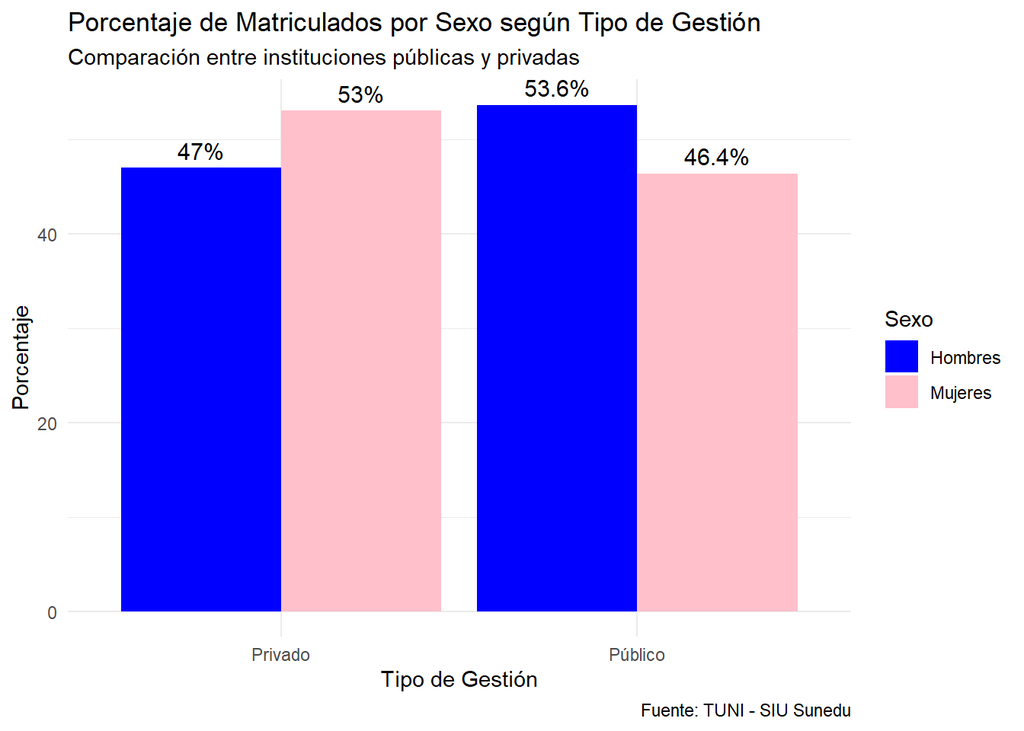

#### 3.4 Distribución de Matriculados (en porcentaje) en diferentes rangos de edad: menores de 17 años, 18 a 24, 25 a 29, 30 a 35, y mayores de 36.

[figure not shown]

#### 3.5. Porcentaje de alumnos con discapacidad por tipo de gestión a nivel nacional, a nivel de Lima Metropolitana (“Lima” en columna de Provincia) y a nivel de provincias (todas las provincias en columna de “Provincia” a excepción de Lima)

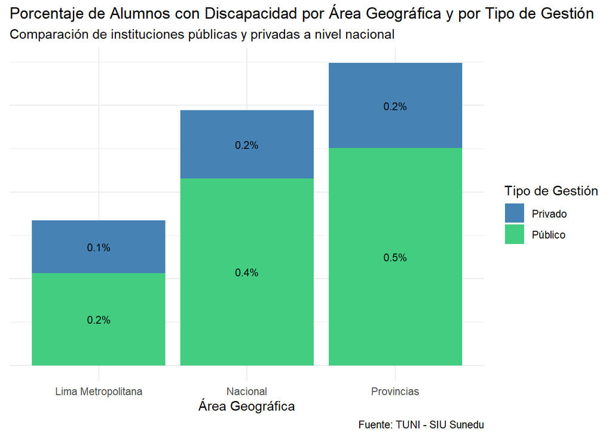

## 4. CONCLUSIONES GENERALES

En el análisis descriptivo de los datos, se identificó un total de 16 variables, de las cuales 7 son categóricas y 9 numéricas. Entre las variables categóricas se incluyen aspectos como género, tipo de gestión universitaria (privada o pública), grupos de programas académicos y espacio geográfico. Asimismo, se analizó la variable relacionada con la presencia de estudiantes con discapacidad.

El estudio reveló que la mayoría de los estudiantes se encuentran matriculados en universidades de gestión privada, lo que destaca una significativa disparidad en la distribución de estudiantes entre los tipos de gestión. Esta tendencia se mantiene constante al analizar la distribución por grupos de programas académicos, donde también se observa una mayor concentración en la gestión privada.

En cuanto al análisis de la gestión universitaria, se observó que tanto hombres como mujeres presentan una mayor tendencia a matricularse en universidades de gestión privada, comparado con la gestión pública. Esta preferencia es especialmente marcada entre las mujeres. Adicionalmente, al analizar la variable de discapacidad, se identificó que la proporción de estudiantes con discapacidad es relativamente baja y está distribuida de manera desigual entre los distintos tipos de gestión y programas académicos. Esto podría reflejar barreras de acceso o falta de adecuaciones necesarias en algunas instituciones.

En resumen, el análisis subraya la predominancia de la gestión privada en el panorama universitario, así como una distribución desigual de la matrícula entre géneros, tipos de gestión y grupos de programas. La baja proporción de estudiantes con discapacidad destaca la necesidad de mejorar la inclusión en el ámbito educativo. Estos resultados sugieren la importancia de un análisis más profundo sobre las causas de estas disparidades y sus implicaciones para la planificación educativa y la equidad en el acceso a la educación superior.